# B11 · Same facts, different computation

**PROVIDED:** source blocks and sealed saved evidence. **TODO:** implement three live operations. **CHECK:** immediate behavioral feedback. **EXIT:** defend a fair comparison.

Fresh execution is CPU mechanism verification and saved-evidence replay, not new benchmark training. Primary readings: [RelGNN §3](https://arxiv.org/html/2502.06784v2), [RelGT §3/Table6](https://arxiv.org/html/2505.10960v1).

```python
# @colab-bootstrap — no repository imports or downloads of private data.
import importlib.util, subprocess, sys, os, tempfile, types, math, json
from pathlib import Path
for package, pip_name in [('torch','torch'),('torch_geometric','torch-geometric'),('einops','einops'),('numpy','numpy')]:
    if importlib.util.find_spec(package) is None:
        subprocess.check_call([sys.executable,'-m','pip','install',pip_name])
import torch
torch.set_num_threads(1)
workspace=Path(tempfile.mkdtemp(prefix='b11-lab-'));os.chdir(workspace);sys.path.insert(0,str(workspace))
Path('evidence/b11').mkdir(parents=True)
print('Author runtime: torch 2.13.0+cpu; current runtime:',torch.__version__)
```

```
Author runtime: torch 2.13.0+cpu; current runtime: 2.13.0+cpu
```

## Recall and worked trace

A purchase row points to a customer and product. A query combines entity identity with a cutoff. Product features2,6 and purchase features1,3 yield route-specific purchase values3,9 under identity scalar transforms. Equal customer attention gives6. Equal attention over customer0 and all four other tokens gives2.4. These simplified updates are not benchmark predictions.

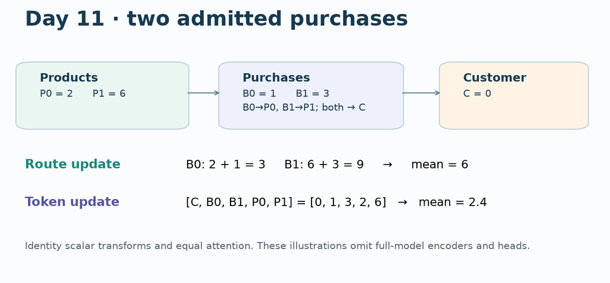

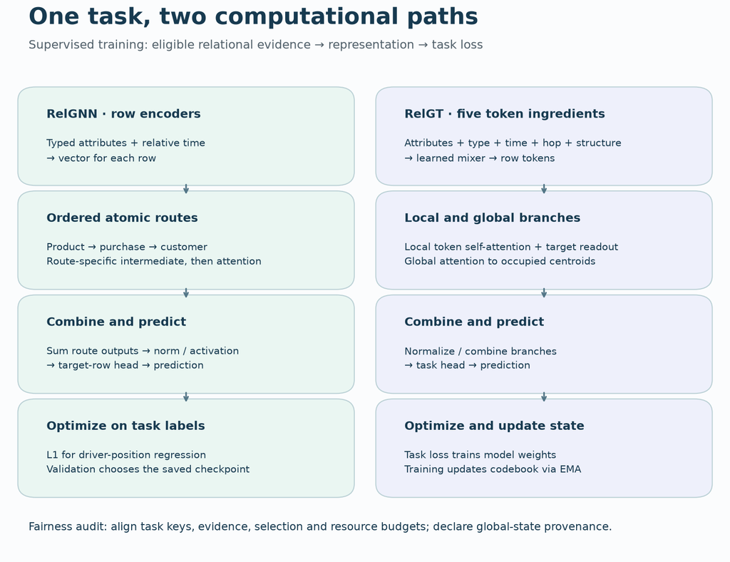

## Inspectable source packet

The packet includes pinned original sources, licenses, full prior models/trainers, protocols and all11 prediction populations. Its digest protects transport; source and L143 evidence have additional inherited hash checks. The L146 prediction seal is newly made in B11. No historical checkpoint identity follows from this seal.

```python
import base64, hashlib, io, zipfile
packet=base64.b64decode('UEsDBBQAAAAIAMatQ11rH1sLDwIAAAEHAAAeAAAAc291cmNlcy9iMTEvcmVs…=')
assert hashlib.sha256(packet).hexdigest()=='0285292a42370d4269c63f9dce7afe063fba7c115fb9d42ccbf2c4034fc24ebd'
with zipfile.ZipFile(io.BytesIO(packet)) as z:
    assert all(not Path(n).is_absolute() and ".." not in Path(n).parts for n in z.namelist())
    z.extractall(workspace)
print("Verified source/evidence packet")
```

```
Verified source/evidence packet
```

## TODO · eligible

Return a boolean mask requiring finite event AND arrival times, each no later than cutoff. Reject unknown times. This fixture policy is stricter than merely checking event time.

```python
def eligible(event, arrival, cutoff):
    """Strict course policy: both clocks must be known and no later than cutoff."""
    return torch.isfinite(event) & torch.isfinite(arrival) & (event<=cutoff) & (arrival<=cutoff)
```

```python
def check_eligible(fn):
    e=torch.tensor([7.,8.,12.,10.]);a=torch.tensor([7.,11.,9.,10.])
    assert fn(e,a,10.).tolist()==[True,False,False,True]
    assert not fn(torch.tensor([float('nan')]),torch.tensor([1.]),10.).any()
check_eligible(eligible)
print("CHECK passed: eligible")
```

```
CHECK passed: eligible
```

## TODO · explicit_attention

Compute QKᵀ/√d, apply an allowed boolean mask (or additive float bias), softmax, then multiply V. Empty allowed sets return zero. Reject nonzero attention dropout and causal mode in this declared lab.

```python
def explicit_attention(q, k, v, attn_mask=None, dropout_p=0., is_causal=False):
    """Visible scaled dot-product attention; empty allowed sets return zero.

    B11 uses zero attention dropout, matching the selected source block setting.
    A boolean mask says allowed; a floating mask adds a score bias.
    """
    if dropout_p or is_causal:
        raise ValueError('B11 checks noncausal attention with zero attention dropout')
    scores=q @ k.transpose(-1,-2) / math.sqrt(q.shape[-1])
    if attn_mask is not None:
        scores=scores.masked_fill(~attn_mask,-torch.inf) if attn_mask.dtype==torch.bool else scores+attn_mask
    empty=torch.isneginf(scores).all(-1,keepdim=True)
    weights=torch.softmax(scores.masked_fill(empty,0.),dim=-1).masked_fill(empty,0.)
    return weights @ v
```

```python
def check_attention(fn):
    q=torch.zeros(1,1,2,2,dtype=torch.float64)
    k=q.clone();v=torch.tensor([[[[2.,4.],[6.,8.]]]],dtype=torch.float64)
    mask=torch.tensor([[True,False],[False,False]])
    out=fn(q,k,v,attn_mask=mask)
    torch.testing.assert_close(out,torch.tensor([[[[2.,4.],[0.,0.]]]],dtype=torch.float64))
    v[...,1,:]=9999;torch.testing.assert_close(fn(q,k,v,attn_mask=mask),out)
    torch.testing.assert_close(fn(q,k,v),v.mean(-2,keepdim=True).expand_as(q))
check_attention(explicit_attention)
print("CHECK passed: explicit_attention")
```

```
CHECK passed: explicit_attention
```

## TODO · first_validation_min

Return the zero-based first occurrence of minimum validation MAE. Reject empty or nonfinite histories. Do not accept test scores.

```python
def first_validation_min(scores):
    """Return zero-based first best epoch; test scores cannot enter this API."""
    if not scores or not all(math.isfinite(float(s)) for s in scores):
        raise ValueError('Require a nonempty finite validation history')
    return min(range(len(scores)),key=lambda i:scores[i])
```

```python
def check_selection(fn):
    assert fn([3.,1.,1.,2.])==1
    for bad in [[],[float('nan')],[float('inf')]]:
        try:fn(bad)
        except ValueError:pass
        else:raise AssertionError('Reject empty/nonfinite validation history')
check_selection(first_validation_min)
print("CHECK passed: first_validation_min")
```

```
CHECK passed: first_validation_min
```

## PROVIDED · Wire your functions into the model and audit

The following module exports your live functions. The source blocks and saved-run audit import these exact objects; TODOs are not decorative exercises.

```python
pkg=types.ModuleType("relkit");pkg.__path__=[];sys.modules["relkit"]=pkg
live=types.ModuleType("relkit.baselines_b11")
for name in ["eligible","explicit_attention","first_validation_min"]:
    setattr(live,name,globals()[name])
sys.modules["relkit.baselines_b11"]=live
```

## PROVIDED · Visible RelGNN composite arithmetic

MIT upstream license is in the extracted archive. B11 supplies encoded vectors and freezes global buffers in evaluation. It does not claim full row-encoder or EMA-update parity.

```python
%%writefile sources/b11/relgnn_visible.py
import math
import torch
from torch_geometric.nn.dense.linear import Linear
from torch_geometric.nn.conv import TransformerConv, SAGEConv
def destination_softmax(scores, destination, num_destinations):
    """Normalize each head over incoming messages for the same destination."""
    index = destination[:, None].expand_as(scores)
    maxima = scores.new_full((num_destinations, scores.shape[1]), -torch.inf)
    maxima.scatter_reduce_(0, index, scores.detach(), reduce='amax', include_self=True)
    weights = (scores - maxima[destination]).exp()
    totals = scores.new_zeros((num_destinations, scores.shape[1]))
    totals.index_add_(0, destination, weights)
    return weights / (totals[destination] + 1e-16)

class RelGNNConv(TransformerConv):
    def __init__(self, attn_type, in_channels, out_channels, heads, aggr,
                 simplified_MP=False, bias=True, **kwargs):
        super().__init__(in_channels, out_channels, heads, bias=bias, **kwargs)
        if aggr != 'sum' or simplified_MP:
            raise ValueError('This audited lesson implements the selected full sum variant')
        self.attn_type = attn_type
        if attn_type == 'dim-fact-dim':
            self.aggr_conv = SAGEConv(in_channels, out_channels, aggr=aggr)
        self.simplified_MP = simplified_MP
        self.final_proj = Linear(heads * out_channels, out_channels, bias=bias)
        self.final_proj.reset_parameters()

    def attend(self, source, destination, edges):
        # [nodes, heads, channels/head-output]; here each head outputs 128 channels.
        h, c = self.heads, self.out_channels
        q = self.lin_query(destination).view(-1, h, c)
        k = self.lin_key(source).view(-1, h, c)
        v = self.lin_value(source).view(-1, h, c)
        src, dst = edges
        scores = (q[dst] * k[src]).sum(-1) / math.sqrt(c)
        alpha = destination_softmax(scores, dst, len(destination))
        messages = v[src] * alpha[:, :, None]
        aggregate = messages.new_zeros((len(destination), h, c))
        aggregate.index_add_(0, dst, messages)
        # Source defaults: concatenate heads, add a destination skip, then project.
        joined = aggregate.reshape(len(destination), h*c) + self.lin_skip(destination)
        return self.final_proj(joined)

    def forward(self, x, edge_index, edge_attr=None, return_attention_weights=None):
        if edge_attr is not None or return_attention_weights is not None:
            raise ValueError('Selected experiment does not use edge attributes or attention return flags')
        if self.attn_type == 'dim-dim':
            return self.attend(x[0], x[1], edge_index)
        edge_attn, edge_aggr = edge_index
        source, fact, destination = x
        src, dst = edge_aggr
        gathered = source.new_zeros((len(fact), source.shape[1]))
        gathered.index_add_(0, dst, source[src])
        # SAGE sum + transformed fact root; unique to this ordered FK pair.
        intermediate = self.aggr_conv.lin_l(gathered) + self.aggr_conv.lin_r(fact)
        return self.attend(intermediate, destination, edge_attn), intermediate
```

```
Overwriting sources/b11/relgnn_visible.py
```

## PROVIDED · Visible RelGT local/global blocks

MIT upstream license is in the extracted archive. B11 supplies encoded vectors and freezes global buffers in evaluation. It does not claim full row-encoder or EMA-update parity.

```python
%%writefile sources/b11/relgt_visible.py
from relkit.baselines_b11 import explicit_attention
import math
import numpy as np
import torch
from torch import nn
import torch.nn.functional as F
from einops import rearrange
from torch_geometric.nn.dense.linear import Linear

class VectorQuantizerEMA(nn.Module):
    """
    Vector Quantizer with Exponential Moving Average (EMA) for the codebook.
    Adapted from https://github.com/devnkong/GOAT

    Args:
        num_embeddings (int): The number of embeddings in the codebook.
        embedding_dim (int): The dimensionality of each embedding.
        decay (float, optional): The decay rate for the EMA. Defaults to 0.99.

    Attributes:
        _embedding_dim (int): The dimensionality of each embedding.
        _num_embeddings (int): The number of embeddings in the codebook.
        _decay (float): The decay rate for the EMA.
        _embedding (nn.Embedding): The embedding matrix.
        _ema_cluster_size (torch.Tensor): The exponential moving average of the cluster sizes.
        _ema_w (torch.Tensor): The exponential moving average of the embedding updates.
    """

    def __init__(self, num_embeddings, embedding_dim, decay=0.99):
        super(VectorQuantizerEMA, self).__init__()

        self._embedding_dim = embedding_dim
        self._num_embeddings = num_embeddings

        self.register_buffer(
            "_embedding", torch.randn(self._num_embeddings, self._embedding_dim)
        )
        self.register_buffer(
            "_embedding_output",
            torch.randn(self._num_embeddings, self._embedding_dim),
        )
        self.register_buffer("_ema_cluster_size", torch.zeros(num_embeddings))
        self.register_buffer(
            "_ema_w", torch.randn(self._num_embeddings, self._embedding_dim)
        )

        self._decay = decay
        self.bn = torch.nn.BatchNorm1d(self._embedding_dim, affine=False)

    def reset_parameters(self):
        nn.init.normal_(self._embedding, mean=0.0, std=1.0)
        nn.init.normal_(self._embedding_output, mean=0.0, std=1.0)
        nn.init.zeros_(self._ema_cluster_size)
        nn.init.normal_(self._ema_w, mean=0.0, std=1.0)

        self.bn.reset_parameters()

    def get_k(self):
        """
        Returns the key tensor of the embedding matrix.
        """
        return self._embedding_output

    def get_v(self):
        """
        Returns the value tensor of the embedding matrix.
        """
        return self._embedding_output[:, : self._embedding_dim]

    def update(self, x):
        inputs_normalized = self.bn(x)
        embedding_normalized = self._embedding

        # Calculate distances
        distances = (
            torch.sum(inputs_normalized**2, dim=1, keepdim=True)
            + torch.sum(embedding_normalized**2, dim=1)
            - 2 * torch.matmul(inputs_normalized, embedding_normalized.t())
        )

        # Encoding
        encoding_indices = torch.argmin(distances, dim=1).unsqueeze(1)
        encodings = torch.zeros(
            encoding_indices.shape[0], self._num_embeddings, device=x.device
        )
        encodings.scatter_(1, encoding_indices, 1)

        # Use EMA to update the embedding vectors
        if self.training:
            self._ema_cluster_size.data = self._ema_cluster_size * self._decay + (
                1 - self._decay
            ) * torch.sum(encodings, 0)

            # Laplace smoothing of the cluster size
            n = torch.sum(self._ema_cluster_size.data)
            self._ema_cluster_size.data = (
                (self._ema_cluster_size + 1e-5) / (n + self._num_embeddings * 1e-5) * n
            )

            dw = torch.matmul(encodings.t(), inputs_normalized)
            self._ema_w.data = self._ema_w * self._decay + (1 - self._decay) * dw
            self._embedding.data = self._ema_w / self._ema_cluster_size.unsqueeze(1)

            running_std = torch.sqrt(self.bn.running_var + 1e-5).unsqueeze(dim=0)
            running_mean = self.bn.running_mean.unsqueeze(dim=0)
            self._embedding_output.data = self._embedding * running_std + running_mean

        return encoding_indices
class LocalModule(nn.Module):
    def __init__(
        self,
        seq_len,
        input_dim,
        node_only_readout=False,
        n_layers=1,
        num_heads=8,
        hidden_dim=64,
        dropout_rate=0.3,
        attention_dropout_rate=0,
    ):
        super().__init__()

        self.seq_len = seq_len
        self.node_only_readout = node_only_readout
        self.input_dim = input_dim
        self.hidden_dim = hidden_dim
        self.ffn_dim = 2 * hidden_dim
        self.num_heads = num_heads

        self.n_layers = n_layers

        self.dropout_rate = dropout_rate
        self.attention_dropout_rate = attention_dropout_rate

        self.att_embeddings_nope = nn.Linear(self.input_dim, self.hidden_dim)

        encoders = [
            EncoderLayer(
                self.hidden_dim,
                self.ffn_dim,
                self.dropout_rate,
                self.attention_dropout_rate,
                self.num_heads,
            )
            for _ in range(self.n_layers)
        ]
        self.layers = nn.ModuleList(encoders)
        self.final_ln = nn.LayerNorm(hidden_dim)

        self.attn_layer = nn.Linear(2 * hidden_dim, 1)

    def reset_parameters(self):
        self.att_embeddings_nope.reset_parameters()
        self.attn_layer.reset_parameters()
        self.final_ln.reset_parameters()
        for layer in self.layers:
            layer.reset_parameters()

    def forward(self, batched_data, pretrain_token=False):
        tensor = self.att_embeddings_nope(batched_data)

        # transformer encoder
        for enc_layer in self.layers:
            tensor = enc_layer(tensor)

        output = self.final_ln(tensor)

        if pretrain_token:
            return output

        _target = output[:, 0, :].unsqueeze(1).repeat(1, self.seq_len - 1, 1)
        split_tensor = torch.split(output, [1, self.seq_len - 1], dim=1)
```

```python
        node_tensor = split_tensor[0]
        _neighbor_tensor = split_tensor[1]

        if self.node_only_readout:
            indices = torch.arange(1, self.seq_len, 1)
            neighbor_tensor = _neighbor_tensor[:, indices]
            target = _target[:, indices]
        else:
            target = _target
            neighbor_tensor = _neighbor_tensor

        layer_atten = self.attn_layer(torch.cat((target, neighbor_tensor), dim=2))
        layer_atten = F.softmax(layer_atten, dim=1)

        neighbor_tensor = neighbor_tensor * layer_atten
        neighbor_tensor = torch.sum(neighbor_tensor, dim=1, keepdim=True)

        output = (node_tensor + neighbor_tensor).squeeze()

        return output

class FeedForwardNetwork(nn.Module):
    def __init__(self, hidden_size, ffn_size, dropout_rate):
        super(FeedForwardNetwork, self).__init__()

        self.bn_in = nn.BatchNorm1d(hidden_size)
        self.bn_out = nn.BatchNorm1d(hidden_size)

        self.ffn_net = nn.Sequential(
            nn.Linear(hidden_size, ffn_size),
            nn.GELU(),
            nn.Dropout(dropout_rate),
            nn.Linear(ffn_size, hidden_size),
            nn.Dropout(dropout_rate)
        )

    def reset_parameters(self):
        for layer in self.ffn_net:
            if hasattr(layer, 'reset_parameters'):
                layer.reset_parameters()

    def forward(self, x):
        x = x.permute(0, 2, 1)
        x = self.bn_in(x)
        x = x.permute(0, 2, 1)

        x = self.ffn_net(x)

        x = x.permute(0, 2, 1)
        x = self.bn_out(x)
        x = x.permute(0, 2, 1)

        return x

class EncoderLayer(nn.Module):
    def __init__(self, hidden_size, ffn_size, dropout_rate, attention_dropout_rate, num_heads):
        super(EncoderLayer, self).__init__()
        self.hidden_size = hidden_size
        self.num_heads = num_heads
        self.attention_dropout_rate = attention_dropout_rate

        self.self_attention_norm = nn.LayerNorm(hidden_size)

        self.q_proj = nn.Linear(hidden_size, hidden_size)
        self.k_proj = nn.Linear(hidden_size, hidden_size)
        self.v_proj = nn.Linear(hidden_size, hidden_size)
        self.out_proj = nn.Linear(hidden_size, hidden_size)

        self.self_attention_dropout = nn.Dropout(dropout_rate)

        self.ffn_norm = nn.LayerNorm(hidden_size)
        self.ffn = FeedForwardNetwork(hidden_size, ffn_size, dropout_rate)

    def reset_parameters(self):
        self.self_attention_norm.reset_parameters()

        for proj in [self.q_proj, self.k_proj, self.v_proj, self.out_proj]:
            nn.init.xavier_uniform_(proj.weight)
            if proj.bias is not None:
                nn.init.zeros_(proj.bias)
        self.ffn_norm.reset_parameters()
        self.ffn.reset_parameters()

    def forward(self, x, attn_bias=None):
        # self-attention block with flash attention
        residual = x
        x_norm = self.self_attention_norm(x)  # [B, L, D]

        Q = self.q_proj(x_norm)  # [B, L, D]
        K = self.k_proj(x_norm)
        V = self.v_proj(x_norm)
        B, L, D = Q.shape
        head_dim = D // self.num_heads

        # reshape Q, K, V to shape [B, num_heads, L, head_dim].
        Q = Q.view(B, L, self.num_heads, head_dim).transpose(1, 2)
        K = K.view(B, L, self.num_heads, head_dim).transpose(1, 2)
        V = V.view(B, L, self.num_heads, head_dim).transpose(1, 2)

        # PyTorch’s fast scaled dot-product attention (flash attention).
        attn_output = explicit_attention(
            Q, K, V,
            attn_mask=attn_bias,
            dropout_p=self.attention_dropout_rate,
            is_causal=False
        )  # Returns [B, num_heads, L, head_dim]

        # reshape back to [B, L, D].
        attn_output = attn_output.transpose(1, 2).reshape(B, L, D)

        attn_output = self.out_proj(attn_output)
        attn_output = self.self_attention_dropout(attn_output)

        x = residual + attn_output

        # Feed-forward block
        residual = x
        x_norm = self.ffn_norm(x)
        ffn_output = self.ffn(x_norm)
        x = residual + ffn_output
        return x
class RelGTLayer(nn.Module):
    def __init__(
        self,
        in_channels,
        out_channels,
        local_num_layers,
        global_dim,
        num_nodes,
        heads=1,
        concat=True,
        ff_dropout=0.0,
        attn_dropout=0.0,
        edge_dim=None,
        conv_type="local",
        num_centroids=None,
        sample_node_len=100,
        **kwargs,
    ):
        super(RelGTLayer, self).__init__()

        self.in_channels = in_channels
        self.out_channels = out_channels
        self.local_num_layers = local_num_layers
        self.heads = heads
        self.concat = concat
        self.ff_dropout = ff_dropout
        self.attn_dropout = attn_dropout
        self.edge_dim = edge_dim
        self.conv_type = conv_type
        self.num_centroids = num_centroids
        self._alpha = None
        self.sample_node_len = sample_node_len

        self.local_module = LocalModule(
            seq_len=self.sample_node_len,
            input_dim=in_channels,
            n_layers=local_num_layers,
            num_heads=heads,
            hidden_dim=out_channels,
            dropout_rate=ff_dropout,
            attention_dropout_rate=attn_dropout
        )
        self.layer_norm_local = nn.LayerNorm(out_channels)

        if self.conv_type != "local":
            self.vq = VectorQuantizerEMA(num_centroids, global_dim, decay=0.99)
            c = torch.randint(0, num_centroids, (num_nodes,), dtype=torch.long)
            self.register_buffer("c_idx", c)
            self.attn_fn = F.softmax

            attn_channels = out_channels // heads

            self.lin_proj_g = Linear(in_channels, global_dim)
            self.lin_key_g = Linear(global_dim, heads * attn_channels)
            self.lin_query_g = Linear(global_dim, heads * attn_channels)
            self.lin_value_g = Linear(global_dim, heads * attn_channels)
            self.layer_norm_global = nn.LayerNorm(out_channels)
```

```python
        self.reset_parameters()

    def reset_parameters(self):
        # Reinitialize global attention layers
        if self.conv_type != "local":
            self.lin_proj_g.reset_parameters()
            self.lin_key_g.reset_parameters()
            self.lin_query_g.reset_parameters()
            self.lin_value_g.reset_parameters()
            if hasattr(self, 'vq'):
                self.vq.reset_parameters()

        # Reinitialize LocalModule
        if hasattr(self.local_module, 'reset_parameters'):
            self.local_module.reset_parameters()

    def forward(self, x_set, x, node_indices):
        if self.conv_type == "local":
            out = self.local_forward(x_set)
            out = self.layer_norm_local(out)

        elif self.conv_type == "global":
            out = self.global_forward(x, node_indices)
            out = self.layer_norm_global(out)

        elif self.conv_type == "full":
            out_local = self.local_forward(x_set)
            out_global = self.global_forward(x, node_indices)
            out_local = self.layer_norm_local(out_local)
            out_global = self.layer_norm_global(out_global)
            out = torch.cat([out_local, out_global], dim=1)

        else:
            raise NotImplementedError

        return out

    def global_forward(self, x, batch_idx):
        d, h = self.out_channels, self.heads
        scale = 1.0 / math.sqrt(d)

        q_x = self.lin_proj_g(x)

        k_buf = self.vq.get_k()
        k_x = k_buf.detach().clone()
        v_buf = self.vq.get_v()
        v_x = v_buf.detach().clone()


        q = self.lin_query_g(q_x)
        k = self.lin_key_g(k_x)
        v = self.lin_value_g(v_x)

        q, k, v = map(lambda t: rearrange(t, "n (h d) -> h n d", h=h), (q, k, v))
        dots = torch.einsum("h i d, h j d -> h i j", q, k) * scale

        c, c_count = self.c_idx.unique(return_counts=True)

        centroid_count = torch.zeros(self.num_centroids, dtype=torch.long).to(x.device)
        centroid_count[c.to(torch.long)] = c_count

        dots = dots + torch.log(centroid_count.view(1, 1, -1))

        attn = self.attn_fn(dots, dim=-1)
        attn = F.dropout(attn, p=self.attn_dropout, training=self.training)

        out = torch.einsum("h i j, h j d -> h i d", attn, v)
        out = rearrange(out, "h n d -> n (h d)")

        # Update the centroids
        if self.training:
            x_idx = self.vq.update(q_x)
            self.c_idx[batch_idx] = x_idx.squeeze().to(torch.long)

        return out

    def local_forward(self, x_set, pretrain_token=False):
        return self.local_module(x_set, pretrain_token)

    def __repr__(self) -> str:
        return (
            f"{self.__class__.__name__}({self.in_channels}, "
            f"{self.out_channels}, heads={self.heads}, "
            f"local_num_layers={self.local_num_layers})"
        )
```

```
Overwriting sources/b11/relgt_visible.py
```

```python
# IPython writefile normalizes blank-line whitespace. Restore only those bytes;
# refuse any substantive change to the displayed source before authenticating it.
with zipfile.ZipFile(io.BytesIO(packet)) as z:
    for name in ['relgnn_visible','relgt_visible']:
        p=Path('sources/b11')/(name+'.py');original=z.read(str(p))
        assert [s.rstrip() for s in p.read_bytes().splitlines()]==[s.rstrip() for s in original.splitlines()]
        p.write_bytes(original)
```

## CHECK · Three-seed source comparison and interventions

Read the visible checker before running it. No benchmark fits are dispatched.

```python
%%writefile _run_b11.py
"""Three-seed CPU block experiment; no dataset fitting or benchmark predictions."""
import importlib.util,json,sys
from pathlib import Path
import torch
from relkit.baselines_b11 import eligible
P=Path(__file__).resolve().parent;S=P/'sources/b11';E=P/'evidence/b11'
def module(name):
    spec=importlib.util.spec_from_file_location(name,S/(name+'.py'));m=importlib.util.module_from_spec(spec);sys.modules[name]=m;spec.loader.exec_module(m);return m
def compare(a,b,args):
    b.load_state_dict(a.state_dict());a.eval();b.eval()
    aa=[v.detach().clone().requires_grad_(v.is_floating_point()) if isinstance(v,torch.Tensor) else v for v in args]
    bb=[v.detach().clone().requires_grad_(v.is_floating_point()) if isinstance(v,torch.Tensor) else v for v in args]
    # GNN tuple inputs need independent leaves too.
    aa=[tuple(t.detach().clone().requires_grad_() for t in v) if isinstance(v,tuple) else v for v in aa]
    bb=[tuple(t.detach().clone().requires_grad_() for t in v) if isinstance(v,tuple) else v for v in bb]
    # Edge tuples are nested in a list to avoid treating integer edges as features.
    aa=[tuple(v) if isinstance(v,list) else v for v in aa];bb=[tuple(v) if isinstance(v,list) else v for v in bb]
    x=a(*aa);y=b(*bb);xs=x if isinstance(x,tuple) else (x,);ys=y if isinstance(y,tuple) else (y,)
    out=max(float((u-v).abs().max().detach()) for u,v in zip(xs,ys))
    for u,v in zip(xs,ys):torch.testing.assert_close(u,v,atol=1e-9,rtol=0)
    sum(v.square().sum() for v in xs).backward();sum(v.square().sum() for v in ys).backward()
    grads=[]
    for (n,p),(m,q) in zip(a.named_parameters(),b.named_parameters()):
        assert n==m and (p.grad is None)==(q.grad is None)
        if p.grad is not None:
            torch.testing.assert_close(p.grad,q.grad,atol=1e-9,rtol=0);grads.append(float((p.grad-q.grad).abs().max()))
    for x,y in zip(aa,bb):
        for u,v in zip(x if isinstance(x,tuple) else (x,),y if isinstance(y,tuple) else (y,)):
            if isinstance(u,torch.Tensor) and u.is_floating_point() and u.grad is not None:
                torch.testing.assert_close(u.grad,v.grad,atol=1e-9,rtol=0);grads.append(float((u.grad-v.grad).abs().max()))
    return dict(output_error=out,gradient_error=max(grads),active_gradient_tensors=len(grads))
def run():
    torch.set_num_threads(1);G=module('relgnn_visible');GO=module('relgnn_original');T=module('relgt_visible');TO=module('relgt_original');rows=[]
    for seed in range(3):
        torch.manual_seed(seed)
        # Two products, three purchases, two customers. Each purchase has one product and customer.
        x=tuple(torch.randn(n,4,dtype=torch.float64) for n in [2,3,2])
        ea=torch.tensor([[0,1,2],[0,0,1]]);eg=torch.tensor([[0,1,0],[0,1,2]])
        for empty in [False,True]:
            a=G.RelGNNConv('dim-fact-dim',(4,4),4,2,'sum').double();b=GO.RelGNNConv('dim-fact-dim',(4,4),4,2,'sum').double()
            edges=[ea if not empty else ea[:,:0],eg]
            r=compare(a,b,[x,edges]);r.update(seed=seed,model='RelGNN composite',empty_attention=empty);rows.append(r)
        a=T.RelGTLayer(8,8,1,4,6,heads=2,conv_type='full',num_centroids=3,sample_node_len=7).double()
        b=TO.RelGTLayer(8,8,1,4,6,heads=2,conv_type='full',num_centroids=3,sample_node_len=7).double()
        # Populated buffers make the frozen global branch observable. One zero-count centroid is excluded.
        a.c_idx.copy_(torch.tensor([0,0,0,1,1,1]));a.vq._embedding_output.copy_(torch.randn(3,4,dtype=torch.float64))
        allrows=torch.cat(x);order=torch.tensor([[5,0,1,2,3,4,6],[6,0,1,2,3,4,5]])
        # Same seven input rows as the GNN. Duplicate four coordinates to fit two heads.
        # These are supplied encoded vectors, not the paper's five-component row encoder.
        encoded=torch.cat([allrows,allrows],dim=-1);tokens=encoded[order];root=encoded[5:];ids=torch.tensor([0,1])
        r=compare(a,b,[tokens,root,ids]);r.update(seed=seed,model='RelGT local+global',empty_attention=False);rows.append(r)
        with torch.no_grad():
            y=a(tokens,root,ids);perm=torch.tensor([0,3,1,2,6,5,4]);yp=a(tokens[:,perm],root,ids)
            torch.testing.assert_close(y,yp,atol=1e-9,rtol=0)
            r['neighbor_permutation_error']=float((y-yp).abs().max())
            # Same eligible raw rows feed both models; exclude both future and late-arriving records.
            events=torch.tensor([7.]*7+[12.,8.]);arrivals=torch.tensor([7.]*7+[9.,11.]);ok=eligible(events,arrivals,10.)
            raw=torch.cat([allrows,torch.randn(2,4,dtype=torch.float64)]);changed=raw.clone();changed[~ok]=1e6
            kept=changed[ok];encoded2=torch.cat([kept,kept],dim=-1)
            changed_y=a(encoded2[order],encoded2[5:],ids)
            torch.testing.assert_close(y,changed_y,atol=0,rtol=0)
            gn=G.RelGNNConv('dim-fact-dim',(4,4),4,2,'sum').double().eval()
            gy=gn(x,(ea,eg))[0];changed_gy=gn(tuple(kept.split([2,3,2])),(ea,eg))[0]
            torch.testing.assert_close(gy,changed_gy,atol=0,rtol=0)
            r['excluded_input_intervention_error']=float((y-changed_y).abs().max())
            # Reindex product rows and update FK source indices together.
            gp=gn((x[0].flip(0),x[1],x[2]),(ea,torch.stack([1-eg[0],eg[1]])))[0]
            torch.testing.assert_close(gy,gp,atol=1e-9,rtol=0)
            r['relgnn_row_permutation_error']=float((gy-gp).abs().max())
            # Frozen global summaries can carry information not present in a query's local sample.
            a.vq._embedding_output[0].add_(torch.tensor([2.,-3.,5.,1.],dtype=torch.float64))
            r['centroid_intervention_change']=float((a(tokens,root,ids)-y).abs().max())
            assert r['centroid_intervention_change']>1e-8
    result=dict(status='PASS',seeds=[0,1,2],cases=rows,tolerance=1e-9,dtype='float64',scope='Reduced block outputs and active input/parameter gradients against pinned sources. RelGT centroid updates and full row encoders are outside parity scope.',fresh_training='NOT_RUN')
    (E/'mechanism.json').write_text(json.dumps(result,indent=2)+'\n');print(json.dumps(result,indent=2))
    return result
if __name__=='__main__':run()
```

```
Writing _run_b11.py
```

```python
from _run_b11 import run
mechanism=run()
```

```
{
  "status": "PASS",
  "seeds": [
    0,
    1,
    2
  ],
  "cases": [
    {
      "output_error": 0.0,
      "gradient_error": 0.0,
      "active_gradient_tensors": 16,
      "seed": 0,
      "model": "RelGNN composite",
      "empty_attention": false
    },
    {
      "output_error": 0.0,
      "gradient_error": 0.0,
      "active_gradient_tensors": 16,
      "seed": 0,
      "model": "RelGNN composite",
      "empty_attention": true
    },
    {
      "output_error": 6.661338147750939e-16,
      "gradient_error": 5.170749895963556e-15,
      "active_gradient_tensors": 40,
      "seed": 0,
      "model": "RelGT local+global",
      "empty_attention": false,
      "neighbor_permutation_error": 2.7755575615628914e-16,
      "excluded_input_intervention_error": 0.0,
      "relgnn_row_permutation_error": 0.0,
      "centroid_intervention_change": 1.5779689517333733
    },
    {
      "output_error": 0.0,
      "gradient_error": 0.0,
      "active_gradient_tensors": 16,
```

[output cut: 43 more lines]

```
      "active_gradient_tensors": 40,
      "seed": 2,
      "model": "RelGT local+global",
      "empty_attention": false,
      "neighbor_permutation_error": 4.440892098500626e-16,
      "excluded_input_intervention_error": 0.0,
      "relgnn_row_permutation_error": 0.0,
      "centroid_intervention_change": 2.325203969561887
    }
  ],
  "tolerance": 1e-09,
  "dtype": "float64",
  "scope": "Reduced block outputs and active input/parameter gradients against pinned sources. RelGT centroid updates and full row encoders are outside parity scope.",
  "fresh_training": "NOT_RUN"
}
```

## CHECK · Complete saved-prediction replay

Read the visible checker before running it. No benchmark fits are dispatched.

```python
%%writefile _audit_b11.py
"""Independent complete-key saved-evidence audit. No historical reports are mutated."""
import hashlib,json,math
from pathlib import Path
import numpy as np
from relkit.baselines_b11 import first_validation_min
P=Path(__file__).resolve().parent;S=P/'sources/b11';A=S/'archive';E=P/'evidence/b11'
def keyed_metric(keys,y,pkeys,p):
    keys=[tuple(k) for k in keys];pkeys=[tuple(k) for k in pkeys]
    if not keys or len(set(keys))!=len(keys) or len(set(pkeys))!=len(pkeys) or set(keys)!=set(pkeys):raise ValueError('Complete unique entity/cutoff identities required')
    if len(y)!=len(keys) or len(p)!=len(pkeys) or not all(math.isfinite(float(v)) for v in list(y)+list(p)):raise ValueError('Finite aligned scalar values required')
    lookup=dict(zip(pkeys,p));return math.fsum(abs(float(t)-float(lookup[k])) for k,t in zip(keys,y))/len(keys)
def audit():
    ledger=json.loads((S/'source-ledger.json').read_text())
    for n,h in ledger['archive'].items():assert hashlib.sha256((A/n).read_bytes()).hexdigest()==h,n
    for n,h in ledger['extracts'].items():assert hashlib.sha256((S/n).read_bytes()).hexdigest()==h,n
    old=json.loads((A/'evidence/l143/training.json').read_text())
    for n,h in old['source_artifact_hashes'].items():
        f=A/'evidence/l143'/n
        if f.exists():assert hashlib.sha256(f.read_bytes()).hexdigest()==h,n
    rows=[];count=0
    refs={split:np.load(A/f'evidence/l146/prepared/{split}.npz') for split in ['val','test']}
    for group,seeds,arms in [('l143',range(5),['RelGNN reconstructed']),('l146',range(3),['gnn','relgt'])]:
        for arm in arms:
            for seed in seeds:
                root=A/'evidence'/group/(f'seed-{seed}' if group=='l143' else f'fit-{arm}-{seed}')
                r=json.loads((root/'result.json').read_text());z=np.load(root/'predictions.npz')
                assert r['seed']==seed and len(r['history'])==10 and all(h['queries']==7453 for h in r['history'])
                selected=first_validation_min([h['val_mae'] for h in r['history']])+1
                assert selected==r['best_epoch' if group=='l143' else 'selected_epoch']
                row=dict(group=group,arm=arm,seed=seed,selected_epoch=selected)
                for split,n in [('val',499),('test',760)]:
                    ref=refs[split];keys=list(zip(ref['entity'],ref['cutoff']))
                    pkeys=list(zip(z[split+'_entity'],z[split+('_time' if group=='l143' else '_cutoff')]))
                    assert len(pkeys)==n
                    targets=dict(zip(keys,ref['target']))
                    assert all(float(t)==float(targets[k]) for k,t in zip(pkeys,z[split+'_target']))
                    m=keyed_metric(keys,ref['target'],pkeys,z[split+'_pred'])
                    recorded=r['scores'][split]['mae'] if group=='l143' else r['scores'][split]
                    assert abs(m-recorded)<1e-10
                    assert abs(keyed_metric(keys,ref['target'],pkeys[::-1],z[split+'_pred'][::-1])-m)<1e-12
                    row[split]=m;count+=n
                if group=='l143':row['nonfinite_gradient_entries']=sum(r['nonfinite_gradients'].values())
                else:
                    for split in ['val','test']:
                        assert r['context_sha256'][split]==hashlib.sha256((A/f'evidence/l146/prepared/{split}.npz').read_bytes()).hexdigest()
                rows.append(row)
    assert len(rows)==11 and count==13849
    summaries={}
    for arm in ['RelGNN reconstructed','gnn','relgt']:
        rr=[r for r in rows if r['arm']==arm]
        summaries[arm]={s:dict(mean=float(np.mean([r[s] for r in rr])),sample_sd=float(np.std([r[s] for r in rr],ddof=1))) for s in ['val','test']}
    # Sanity tests reject missing/duplicate/nonfinite identities rather than silently joining rows.
    rejected=0
    for keys,p in [([(1,10),(1,10)],[1.,2.]),([(1,10)],[1.]),([(1,10),(1,20)],[float('nan'),2.])]:
        try:keyed_metric([(1,10),(1,20)],[1.,2.],keys,p)
        except ValueError:rejected+=1
    assert rejected==3
    cost=json.loads((A/'evidence/l145/cost-decision.json').read_text())
    assert cost['temporal_status']=='FAIL' and cost['projected_nine_at_shallow_speed_usd']>10
    result=dict(status='COMPLETE_SAVED_EVIDENCE_REPLAY',runs=rows,summaries=summaries,verified_predictions=count,checkpoint_selections=11,invalid_packets_rejected=rejected,labels='Reused L146 task targets; agreement with L143 prediction targets checked. No new raw-database label reconstruction.',RelGT_full_gate='INCOMPLETE_TEMPORAL_AND_BUDGET_GATE',inherited_projection_usd=cost['projected_nine_at_shallow_speed_usd'],fresh_B11_benchmark_training='NOT_RUN',matched_RelGNN_RelGT_benchmark='NOT_RUN',whole_paper='NOT_RUN',learner='PENDING_WRITTEN_DEFENSE')
    E.mkdir(parents=True,exist_ok=True);(E/'replay.json').write_text(json.dumps(result,indent=2)+'\n');print(json.dumps({k:v for k,v in result.items() if k!='runs'},indent=2));return result
if __name__=='__main__':audit()
```

```
Writing _audit_b11.py
```

```python
from _audit_b11 import audit
replay=audit()
```

```
{
  "status": "COMPLETE_SAVED_EVIDENCE_REPLAY",
  "summaries": {
    "RelGNN reconstructed": {
      "val": {
        "mean": 3.1300641224809547,
        "sample_sd": 0.08864337468210115
      },
      "test": {
        "mean": 4.221853429509882,
        "sample_sd": 0.17351165216913544
      }
    },
    "gnn": {
      "val": {
        "mean": 3.197652293302731,
        "sample_sd": 0.0565319786470788
      },
      "test": {
        "mean": 4.293631827329334,
        "sample_sd": 0.037816386010403574
      }
    },
    "relgt": {
      "val": {
        "mean": 3.048311807190329,
        "sample_sd": 0.1027340643490702
      },
      "test": {
        "mean": 4.617535542898011,
        "sample_sd": 0.2911411415605598
      }
    }
  },
  "verified_predictions": 13849,
  "checkpoint_selections": 11,
  "invalid_packets_rejected": 3,
  "labels": "Reused L146 task targets; agreement with L143 prediction targets checked. No new raw-database label reconstruction.",
  "RelGT_full_gate": "INCOMPLETE_TEMPORAL_AND_BUDGET_GATE",
  "inherited_projection_usd": 80.41150089143264,
  "fresh_B11_benchmark_training": "NOT_RUN",
  "matched_RelGNN_RelGT_benchmark": "NOT_RUN",
  "whole_paper": "NOT_RUN",
  "learner": "PENDING_WRITTEN_DEFENSE"
}
```

## Measured evidence

| Checked block | Cases | Maximum output error | Maximum gradient error |
| --- | --- | --- | --- |
| RelGNN composite | 6 | 0.00e+00 | 0.00e+00 |
| RelGT local+global | 3 | 7.22e-16 | 6.15e-15 |

| Archived experiment | Seeds | Validation MAE | Test MAE |
| --- | --- | --- | --- |
| L143 · reconstructed RelGNN | 5 | 3.1301 ± 0.0886 | 4.2219 ± 0.1735 |
| L146 · typed-mean GNN | 3 | 3.1977 ± 0.0565 | 4.2936 ± 0.0378 |
| L146 · reduced corrected RelGT | 3 | 3.0483 ± 0.1027 | 4.6175 ± 0.2911 |

± denotes sample standard deviation across seeds, not a confidence interval. The blocks are separate experiments.

The current mechanism errors can vary slightly by runtime within1e-9. Saved MAEs must match. L143 retained nonfinite source gradients. L146 compares a typed-mean GNN with reduced corrected RelGT; it does not compare RelGNN with RelGT. Full RelGT search remains INCOMPLETE_TEMPORAL_AND_BUDGET_GATE. Fresh B11 benchmark fits and whole-paper reproduction are NOT_RUN.

```python
assert replay["verified_predictions"]==13849 and replay["checkpoint_selections"]==11
assert mechanism["status"]=="PASS"
Path("b11-report.json").write_text(json.dumps({"mechanism":mechanism,"replay":replay},indent=2))
print("Author checks complete; learner defense still required")
```

```
Author checks complete; learner defense still required
```

## EXIT · Your written defense

Explain the two paths, the global-centroid information boundary, and why these saved scores are not a matched RelGNN–RelGT comparison. Specify complete query keys, a validation-only selection rule and a shared information/resource contract. Name a falsifier for your preferred explanation. Revisit tomorrow, in7days and in30days. Ask the teaching agent for feedback.

**Learner: PENDING_WRITTEN_DEFENSE. Live Colab: NOT_CHECKED.** Full reproduction contracts/operators remain in `sources/b11/archive/`; read them before planning any full run. Default execution here allocates no paid compute.